# Lattice Plotting System(Part1)

David Asare Kumi

June 10, 2019

## Lattice Plots

- Different from base plotting system.
- Useful for plotting high dimensional data.
- Using for making many many plots at (panel plots) once.

## Functions of the Lattice Plotting System

The lattice plotting system is implemented using the following packages.

- Lattice: Contains code for producing Trellis graphics which are independent of the base graphics system; includes functions like xyplots,bwplots,levelplots.
- Grid: implements a different graphing system independent of the base system; the lattice package builds on top of grid. We seldom call functions from the grid package directly.
- The lattice plotting system does not have a two phase aspect with separate plotting and annotation like in base plotting.
- All plotting/annotation is done at once with a single function call.
- Some of the main lattice functions include;
1. xyplot; this is the main function for creating scatterplots.
2. bwplot; box and whiskers plots (“boxplots”).
3. histogram; histograms.
4. stripplot; like a boxplot but with actual points.
5. dotplot; plot dots on “violin strings”.
6. Splom; scatterplot matrix - like pairs in base plotting system.
7. levelplot, contourplot; for plotting “image” data.

## Simple lattice plot

```r
library(datasets)
library(lattice)
data(airquality)
names(airquality)
```

```
## [1] "Ozone"   "Solar.R" "Wind"    "Temp"    "Month"   "Day"
```

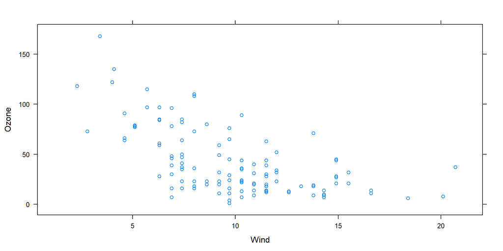

```r
xyplot(Ozone~Wind,data=airquality)
```

```r
#lattice plot involving factor variable
library(lattice)
library(datasets)
data(airquality)
str(airquality)
```

```
## 'data.frame':    153 obs. of  6 variables:
##  $ Ozone  : int  41 36 12 18 NA 28 23 19 8 NA ...
##  $ Solar.R: int  190 118 149 313 NA NA 299 99 19 194 ...
##  $ Wind   : num  7.4 8 12.6 11.5 14.3 14.9 8.6 13.8 20.1 8.6 ...
##  $ Temp   : int  67 72 74 62 56 66 65 59 61 69 ...
##  $ Month  : int  5 5 5 5 5 5 5 5 5 5 ...
##  $ Day    : int  1 2 3 4 5 6 7 8 9 10 ...
```

```r
Month <-as.factor(airquality$Month)
class(Month)
```

```
## [1] "factor"
```

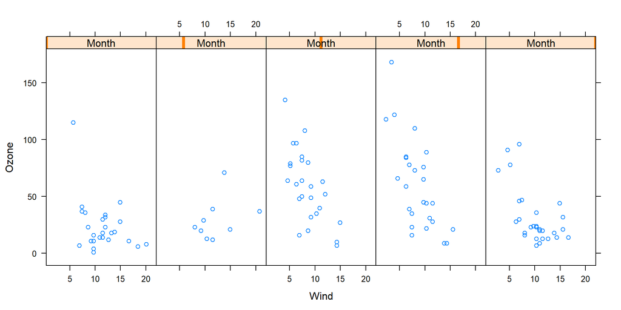

```r
xyplot(Ozone~Wind|Month,data=airquality,layout=c(5,1))
```

## Lattice Plotting System (Part 2)

- Lattice functions have a panel function which controls what happens inside each panel of the plot.
- The lattice package comes with default panel functions, but you can supply your own if you want to customize what happens in each panel.
- Panel functions receive the x/y coordinates of the data points in their panel (along with any optional arguments).

## Custom Panel function

```r
library(lattice)
library(datasets)
data(airquality)
names(airquality)
```

```
## [1] "Ozone"   "Solar.R" "Wind"    "Temp"    "Month"   "Day"
```

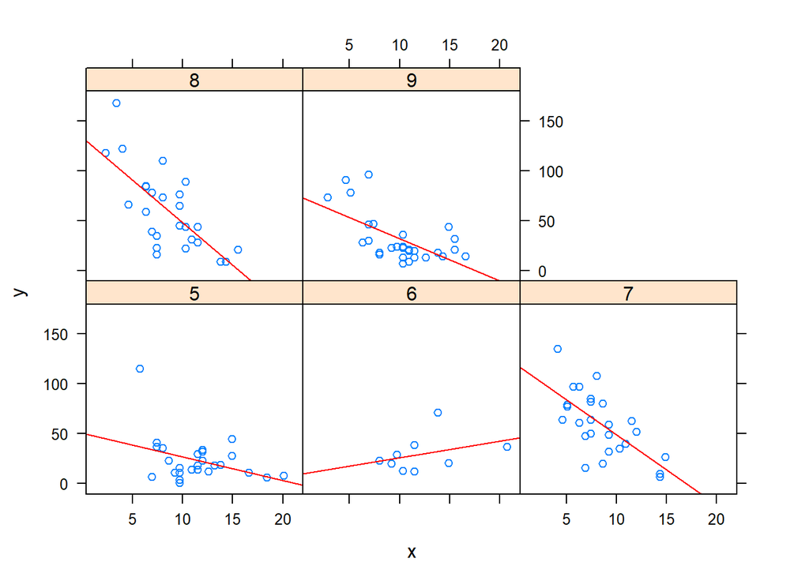

```r
Month <-as.factor(airquality$Month)
x <-airquality$Wind
y <-airquality$Ozone
xyplot(y~x|Month,panel=function(x,y,...){
  panel.xyplot(x,y,...)
  panel.lmline(x,y,col="red")
})
```